## 1. What is covariance and what does it measure in a dataset?

Covariance is a statistical measure that describes how two variables change together. It tells us whether an increase in one variable tends to be associated with an increase or decrease in another variable.

# What covariance tells us:

**Positive covariance (>0)**

- When X increases, Y tends to increase.
- Example: Hours studied vs. marks scored.

**Negative covariance (<0)**

- When X increases, Y tends to decrease.
- Example: Hours spent on TV vs. exam marks.

**Zero covariance (≈ 0):**

- The variables are not linearly related; changes in one do not predict changes in the other.

# Important points:

Covariance only measures direction, not the strength of the relationship.

# 2. What is correlation and how is it different from covariance?

**Correlation vs Covariance**

**1. Covariance**

**Definition:**  
Covariance is a statistical measure that indicates the **direction of the linear relationship** between two variables. It tells whether two variables tend to increase or decrease together.

**Interpretation:**

- **Positive covariance (>0):** Both variables increase or decrease together.
- **Negative covariance (<0):** One variable increases while the other decreases.
- **Covariance ≈ 0:** Little or no linear relationship.

**Limitations:**

- Its value depends on the units of X and Y, making it hard to compare across datasets.

**2. Correlation**

**Definition:**  
Correlation measures both the **strength and direction** of the linear relationship between two variables. It is a **standardized version of covariance** and is unitless, making it easier to interpret.

**Interpretation:**

- **r = 1:** Perfect positive linear relationship
- **r = -1:** Perfect negative linear relationship
- **r ≈ 0:** No linear relationship

**3. Key Differences**

| Feature | Covariance | Correlation |
| --- | --- | --- |
| Measures | Direction of relationship | Direction + Strength |
| Scale | Depends on units | Unitless (standardized) |
| Range | (-∞, +∞) | [-1, 1] |
| Interpretability | Hard to compare | Easy to compare across datasets |

# 3. What is the range of correlation values and what do they indicate?

**r=+1** (Perfect Positive Correlation): A correlation value of +1 indicates a perfect positive linear relationship between two variables. This means that as one variable increases, the other variable increases in exactly the same proportion every time. All data points lie on a straight line sloping upward. Such a relationship is rare in real-world data but can be seen in mathematically related variables, such as temperature measured in Celsius and Fahrenheit.

**0<𝑟<+1** (Positive Correlation): A correlation value between 0 and +1 shows a positive relationship, meaning both variables tend to increase together, though not perfectly. As the value moves closer to +1, the relationship becomes stronger. For example, as study hours increase, exam scores generally increase, but not in an exact pattern for every student.

**𝑟=0** (No Linear Correlation): A correlation value of 0 indicates no linear relationship between the two variables. Changes in one variable do not predict changes in the other in a straight-line manner. However, this does not mean the variables are completely unrelated; there may still be a non-linear relationship present that correlation does not capture.

**−1<𝑟<0** (Negative Correlation): A correlation value between 0 and −1 represents a negative relationship, where one variable tends to decrease as the other increases. The closer the value is to −1, the stronger the inverse relationship. For instance, as the speed of a vehicle increases, the time required to reach a destination generally decreases.

**𝑟=−1** (Perfect Negative Correlation): A correlation value of −1 indicates a perfect negative linear relationship. As one variable increases, the other decreases in exact proportion every time. All data points lie on a straight line sloping downward. Like perfect positive correlation, this is uncommon in real-world datasets but can occur in strictly defined mathematical relationships.

# 4. What does a positive covariance mean?

A positive covariance means that two variables tend to move in the same direction. When one variable increases, the other variable also tends to increase, and when one decreases, the other tends to decrease. It indicates a direct relationship between the variables, but it does not tell how strong the relationship is—only that they change together.

# 5. What does a negative correlation represent in real-world data?

A negative correlation in real-world data represents an inverse relationship between two variables, where an increase in one variable is associated with a decrease in the other. For example, as the number of hours spent watching television increases, students’ study time or academic performance may decrease. This relationship shows that the variables move in opposite directions, though the correlation does not imply that one directly causes the other.

# 6. Why is covariance not normalized?

Covariance is not normalized because its value depends on the units and scale of the variables being measured. Since it is calculated using the original units of both variables, changing the units (for example, meters to centimeters) will change the covariance value, even though the underlying relationship stays the same. This makes covariance difficult to interpret and compare across different datasets. Normalization would remove unit dependence, which is why correlation is used instead it standardizes covariance by dividing it by the product of the variables’ standard deviations.

# 7. Can correlation exist without causation? Explain with an example.

Yes, correlation can exist without causation. This means that two variables may show a relationship or pattern together, but one does not directly cause the other.

Example: The number of mobile phones sold and the number of engineering graduates increase over the years. These two variables are positively correlated because both increase with time, but mobile phone sales do not cause more students to graduate as engineers. The apparent relationship exists due to a common underlying factor-population growth and technological advancement not because one causes the other.

# 8. What does a correlation value close to 0 indicate?

A correlation value close to 0 indicates that there is little to no linear relationship between the two variables in the dataset. This means that changes in one variable do not consistently correspond to increases or decreases in the other variable in a predictable way. However, it is important to note that a correlation near zero does not necessarily imply that the variables are completely unrelated; they may still have a non-linear relationship that correlation does not capture. In short, a correlation value close to zero suggests the absence of a meaningful linear association between the variables

# Coding Exercises

**9. Write a function to compute covariance between two numerical lists from scratch.**

```python
hours_studied = [2, 4, 6, 8, 10]
exam_scores = [50, 60, 65, 70, 85]
def mean(data):
    return sum(data)/ len(data)
def covariance(data1,data2):
    mean1= mean(data1)
    mean2 = mean(data2)

    cov_sum = 0
    for x,y in zip(data1,data2):
        diff1 = x - mean1
        diff2 = y - mean2
        cov_sum+= diff1 * diff2
    cov = cov_sum / (len(data1) - 1)
    return cov

res = covariance(hours_studied,exam_scores)
print("The covariance between 2 numerical column is ",res)
```

```
The covariance between 2 numerical column is  40.0
```

**10. Write a function to compute Pearson correlation using your covariance function**

```python
hours_studied = [2, 4, 6, 8, 10]
exam_scores = [50, 60, 65, 70, 85]
def mean(data):
    return sum(data)/ len(data)

def std_dev(data):
    m = mean(data)
    var = sum((x-m)**2 for x in data) / (len(data) -1)
    return var ** 0.5

def covariance(data1,data2):
    mean1= mean(data1)
    mean2 = mean(data2)

    cov_sum = 0
    for x,y in zip(data1,data2):
        diff1 = x - mean1
        diff2 = y - mean2
        cov_sum+= diff1 * diff2
    cov = cov_sum / (len(data1) - 1)
    return cov

def correlation(x,y):
    covxy = covariance(x,y)
    std1=std_dev(x)
    std2 =std_dev(y)

    corr =covxy / (std1 * std2)
    return corr

output = correlation(hours_studied,exam_scores)
print("The correlation between hours_studied and exam_scores is ", output)
```

```
The correlation between hours_studied and exam_scores is  0.9773555548504417
```

**11. Modify your correlation function to handle unequal list lengths safely.**

```python
hours_studied = [2, 4, 6, 8, 10,13]
exam_scores = [50, 60, 65, 70, 85]
def mean(data):
    return sum(data)/ len(data)

def std_dev(data):
    m = mean(data)
    var = sum((x-m)**2 for x in data) / (len(data) -1)
    return var ** 0.5

def covariance(data1,data2):
    if len(data1) != len(data2):
        raise ValueError("The list must be of same Length")
    mean1= mean(data1)
    mean2 = mean(data2)

    cov_sum = 0
    for x,y in zip(data1,data2):
        diff1 = x - mean1
        diff2 = y - mean2
        cov_sum+= diff1 * diff2
    cov = cov_sum / (len(data1) - 1)
    return cov

def correlation(x,y):

    if len(x) != len(y):
        raise ValueError("The list must be of same Length.")

    covxy = covariance(x,y)
    std1=std_dev(x)
    std2 =std_dev(y)

    corr =covxy / (std1 * std2)
    return corr

output = correlation(hours_studied,exam_scores)
print("The correlation between hours_studied and exam_scores is ", output)
```

```
---------------------------------------------------------------------------
ValueError                                Traceback (most recent call last)
Cell In[18], line 37
     34     corr =covxy / (std1 * std2)
     35     return corr
---> 37 output = correlation(hours_studied,exam_scores)
     38 print("The correlation between hours_studied and exam_scores is ", output)

Cell In[18], line 28, in correlation(x, y)
     25 def correlation(x,y):
     27     if len(x) != len(y):
---> 28         raise ValueError("The list must be of same Length.")
     30     covxy = covariance(x,y)
     31     std1=std_dev(x)

ValueError: The list must be of same Length.
```

**12. Write code to compute a correlation matrix for multiple numeric columns.**

```python
x = [10, 12, 15, 18, 20]
y = [8,  9, 11, 13, 15]
z = [2,  3,  5,  7,  9]

def mean(data):
    return sum(data)/ len(data)

def std_dev(data):
    m = mean(data)
    var = sum((x-m)**2 for x in data) / (len(data) -1)
    return var ** 0.5

def covariance(data1,data2):
    if len(data1) != len(data2):
        raise ValueError("The list must be of same Length")
    mean1= mean(data1)
    mean2 = mean(data2)

    cov_sum = 0
    for x,y in zip(data1,data2):
        diff1 = x - mean1
        diff2 = y - mean2
        cov_sum+= diff1 * diff2
    cov = cov_sum / (len(data1) - 1)
    return cov

def correlation(x,y):

    if len(x) != len(y):
        raise ValueError("The list must be of same Length.")

    covxy = covariance(x,y)
    std1=std_dev(x)
    std2 =std_dev(y)

    corr =covxy / (std1 * std2)
    return corr

matrix = [
    [correlation(x, x), correlation(x, y), correlation(x, z)],
    [correlation(y, x), correlation(y, y), correlation(y, z)],
    [correlation(z, x), correlation(z, y), correlation(z, z)],
]

# Print the matrix in clean format
cols = ["X", "Y", "Z"]
print("     X       Y       Z")
for row_name, row in zip(cols, matrix):
    print(row_name, " ", "  ".join(f"{value:.3f}" for value in row))
```

```
     X       Y       Z
X   1.000  0.995  0.995
Y   0.995  1.000  1.000
Z   0.995  1.000  1.000
```

**13. Implement correlation without using NumPy or Pandas built-in functions.**

```python
hours_studied = [2, 4, 6, 8, 10]
exam_scores = [50, 60, 65, 70, 85]
def mean(data):
    return sum(data)/ len(data)

def std_dev(data):
    m = mean(data)
    var = sum((x-m)**2 for x in data) / (len(data) -1)
    return var ** 0.5

def covariance(data1,data2):
    mean1= mean(data1)
    mean2 = mean(data2)

    cov_sum = 0
    for x,y in zip(data1,data2):
        diff1 = x - mean1
        diff2 = y - mean2
        cov_sum+= diff1 * diff2
    cov = cov_sum / (len(data1) - 1)
    return cov

def correlation(x,y):
    covxy = covariance(x,y)
    std1=std_dev(x)
    std2 =std_dev(y)

    corr =covxy / (std1 * std2)
    return corr

output = correlation(hours_studied,exam_scores)
print("The correlation between hours_studied and exam_scores is ", output)
```

```
The correlation between hours_studied and exam_scores is  0.9773555548504417
```

**14. Add error handling if input data contains missing values.**

```python
hours_studied = [2, 4, 6, 8, 10]        # Example data
exam_scores = [50, 60, 65, None, 85]   # Example with a missing value

def filter_valid_pairs(data1, data2):
    """Return only pairs where both values are not None."""
    return [(x, y) for x, y in zip(data1, data2) if x is not None and y is not None]

def mean(data):
    return sum(data) / len(data)

def std_dev(data):
    # see this len(data) /2 we have done because i have taken sample standard deviation if i used population then this step is removed.
    if len(data) < 2:
        raise ValueError("Not enough data to compute standard deviation.")
    m = mean(data)
    var = sum((x - m) ** 2 for x in data) / (len(data) - 1)   # if len =1 1-1 = 0 error to remove this above line is used now clear?
    return var ** 0.5

def covariance(data1, data2):
    if len(data1) != len(data2):
        raise ValueError("Lists must be of same length.")
    clean_pairs = filter_valid_pairs(data1, data2)
    if len(clean_pairs) < 2:
        raise ValueError("Not enough valid data to compute covariance.")

    data1_clean, data2_clean = zip(*clean_pairs)
    mean1 = mean(data1_clean)
    mean2 = mean(data2_clean)

    cov_sum = sum((x - mean1) * (y - mean2) for x, y in zip(data1_clean, data2_clean))
    return cov_sum / (len(data1_clean) - 1)

def correlation(data1, data2):
    clean_pairs = filter_valid_pairs(data1, data2)
    if len(clean_pairs) < 2:
        raise ValueError("Not enough valid data to compute correlation.")

    data1_clean, data2_clean = zip(*clean_pairs)

    covxy = covariance(data1_clean, data2_clean)
    std1 = std_dev(data1_clean)
    std2 = std_dev(data2_clean)

    if std1 == 0 or std2 == 0:
        raise ValueError("Standard deviation is zero, correlation undefined.")

    return covxy / (std1 * std2)

# Compute correlation safely
output = correlation(hours_studied, exam_scores)
print("Correlation with missing value handling:", round(output, 3))
```

```
Correlation with missing value handling: 0.994
```

**15. Write a function that returns correlation rounded to 2 decimal places.**

```python
def correlation_rounded(data1, data2):
    """
    Compute Pearson correlation coefficient between two lists,
    handling missing values, and return rounded to 2 decimal places.
    """
    # Remove pairs where either value is None
    clean_pairs = [(x, y) for x, y in zip(data1, data2) if x is not None and y is not None]

    if len(clean_pairs) < 2:
        raise ValueError("Not enough valid data to compute correlation.")

    # Unpack the cleaned pairs
    data1_clean, data2_clean = zip(*clean_pairs)

    # Compute means
    mean1 = sum(data1_clean) / len(data1_clean)
    mean2 = sum(data2_clean) / len(data2_clean)

    # Compute covariance
    cov = sum((x - mean1) * (y - mean2) for x, y in zip(data1_clean, data2_clean)) / (len(data1_clean) - 1)

    # Compute standard deviations
    std1 = (sum((x - mean1)**2 for x in data1_clean) / (len(data1_clean) - 1)) ** 0.5
    std2 = (sum((y - mean2)**2 for y in data2_clean) / (len(data2_clean) - 1)) ** 0.5

    # Compute correlation
    corr = cov / (std1 * std2)

    # Round to 2 decimal places
    return round(corr, 2)


# Example usage
hours_studied = [2, 4, 6, 8, 10]
exam_scores = [50, 60, 65, None, 85]

result = correlation_rounded(hours_studied, exam_scores)
print("Correlation (rounded to 2 decimals):", result)
```

```
Correlation (rounded to 2 decimals): 0.99
```

**16. Compute correlation before and after removing outliers and compare results.**

```python
# Example datasets with outliers
hours_studied = [2, 3, 4, 5, 6, 7, 8, 50]   # 50 is an outlier
exam_scores = [50, 55, 60, 65, 70, 75, None, 100]  # 100 is an outlier

# Function to compute correlation (handles missing values)
def correlation(data1, data2):
    clean_pairs = [(x, y) for x, y in zip(data1, data2) if x is not None and y is not None]
    data1_clean, data2_clean = zip(*clean_pairs)

    mean1 = sum(data1_clean)/len(data1_clean)
    mean2 = sum(data2_clean)/len(data2_clean)

    cov = sum((x - mean1)*(y - mean2) for x, y in zip(data1_clean, data2_clean)) / (len(data1_clean)-1)
    std1 = (sum((x - mean1)**2 for x in data1_clean) / (len(data1_clean)-1)) ** 0.5
    std2 = (sum((y - mean2)**2 for y in data2_clean) / (len(data2_clean)-1)) ** 0.5

    return cov / (std1*std2)

# Function to remove outliers using IQR
def remove_outliers(data):
    data=[x for x in data if x is not None]
    q1 = sorted(data)[len(data)//4]
    q3 = sorted(data)[3*len(data)//4]
    iqr = q3 - q1
    lower = q1 - 1.5*iqr
    upper = q3 + 1.5*iqr
    return [x for x in data if lower <= x <= upper]

# Correlation before removing outliers
corr_before = correlation(hours_studied, exam_scores)
print("Correlation before removing outliers:", round(corr_before, 2))

# Remove outliers from both lists (aligned)
clean_pairs = [(x, y) for x, y in zip(hours_studied, exam_scores)
               if x in remove_outliers(hours_studied) and y in remove_outliers(exam_scores)]
# if clean_pairs:
hours_clean, scores_clean = zip(*clean_pairs)
corr_after = correlation(hours_clean, scores_clean)
print("Correlation after removing outliers:", round(corr_after, 2))
```

```
Correlation before removing outliers: 0.9
Correlation after removing outliers: 1.0
```

**17. Write code to verify symmetry of the correlation matrix.**

```python
# Example data
x = [10, 12, 15, 18, 20]
y = [8, 9, 11, 13, 15]
z = [2, 3, 5, 7, 9]

# Function to compute correlation (without numpy/pandas)
def mean(data):
    return sum(data)/len(data)

def std_dev(data):
    m = mean(data)
    var = sum((x-m)**2 for x in data)/(len(data)-1)
    return var**0.5

def covariance(data1, data2):
    mean1 = mean(data1)
    mean2 = mean(data2)
    cov_sum = sum((a - mean1)*(b - mean2) for a,b in zip(data1, data2))
    return cov_sum/(len(data1)-1)

def correlation(data1, data2):
    return covariance(data1, data2)/(std_dev(data1)*std_dev(data2))

# Build correlation matrix
matrix = [
    [correlation(x,x), correlation(x,y), correlation(x,z)],
    [correlation(y,x), correlation(y,y), correlation(y,z)],
    [correlation(z,x), correlation(z,y), correlation(z,z)]
]

# Verify symmetry
is_symmetric = False
n = len(matrix)
print(n)
for i in range(n):
    for j in range(n):
        if matrix[i][j] == matrix[j][i]:
            is_symmetric = True
            break

# Print matrix
print("Correlation Matrix:")
for row in matrix:
    print([round(val,3) for val in row])

# Print symmetry check
print("Is the correlation matrix symmetric?", is_symmetric)
```

```
3
Correlation Matrix:
[1.0, 0.995, 0.995]
[0.995, 1.0, 1.0]
[0.995, 1.0, 1.0]
Is the correlation matrix symmetric? True
```

**18. Save the correlation matrix as a CSV file.**

```python
import csv

# Example correlation matrix
matrix = [
    [1, 0.9, 0.8],
    [0.9, 1, 0.7],
    [0.8, 0.7, 1]
]

# Optional: column/row names
cols = ["X", "Y", "Z"]

# Save to CSV
with open("correlation_matrix.csv", "w", newline="") as f:
    writer = csv.writer(f)

    # Write header
    writer.writerow([""] + cols)

    # Write rows
    for name, row in zip(cols, matrix):
        writer.writerow([name] + [round(val, 3) for val in row])

print("Correlation matrix saved as 'correlation_matrix.csv'")
```

```
Correlation matrix saved as 'correlation_matrix.csv'
```

## Visualization /Analyis (19-20)

**19. Plot a correlation heatmap for numerical columns.**

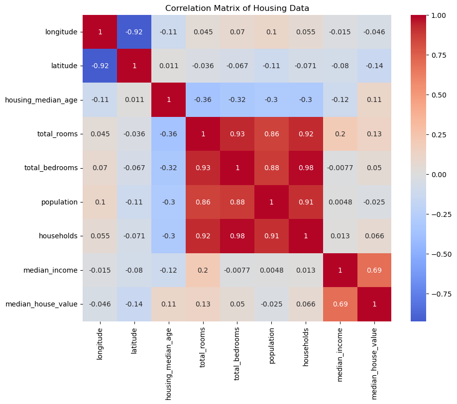

```python
#using libraries for housing dataset
import seaborn as sns
import pandas as pd
import matplotlib.pyplot as plt
df =pd.read_csv("housing.csv")
corr_matrix = df.corr(numeric_only=True)
plt.figure(figsize=(10,8))
sns.heatmap(corr_matrix, annot=True, cmap="coolwarm", center=0)
plt.title("Correlation Matrix of Housing Data")
plt.show()
```

```python
df
```

|  | longitude | latitude | housing_median_age | total_rooms | total_bedrooms | population | households | median_income | median_house_value | ocean_proximity |
| --- | --- | --- | --- | --- | --- | --- | --- | --- | --- | --- |
| 0 | -122.23 | 37.88 | 41.0 | 880.0 | 129.0 | 322.0 | 126.0 | 8.3252 | 452600.0 | NEAR BAY |
| 1 | -122.22 | 37.86 | 21.0 | 7099.0 | 1106.0 | 2401.0 | 1138.0 | 8.3014 | 358500.0 | NEAR BAY |
| 2 | -122.24 | 37.85 | 52.0 | 1467.0 | 190.0 | 496.0 | 177.0 | 7.2574 | 352100.0 | NEAR BAY |
| 3 | -122.25 | 37.85 | 52.0 | 1274.0 | 235.0 | 558.0 | 219.0 | 5.6431 | 341300.0 | NEAR BAY |
| 4 | -122.25 | 37.85 | 52.0 | 1627.0 | 280.0 | 565.0 | 259.0 | 3.8462 | 342200.0 | NEAR BAY |
| ... | ... | ... | ... | ... | ... | ... | ... | ... | ... | ... |
| 20635 | -121.09 | 39.48 | 25.0 | 1665.0 | 374.0 | 845.0 | 330.0 | 1.5603 | 78100.0 | INLAND |
| 20636 | -121.21 | 39.49 | 18.0 | 697.0 | 150.0 | 356.0 | 114.0 | 2.5568 | 77100.0 | INLAND |
| 20637 | -121.22 | 39.43 | 17.0 | 2254.0 | 485.0 | 1007.0 | 433.0 | 1.7000 | 92300.0 | INLAND |
| 20638 | -121.32 | 39.43 | 18.0 | 1860.0 | 409.0 | 741.0 | 349.0 | 1.8672 | 84700.0 | INLAND |
| 20639 | -121.24 | 39.37 | 16.0 | 2785.0 | 616.0 | 1387.0 | 530.0 | 2.3886 | 89400.0 | INLAND |

20640 rows × 10 columns

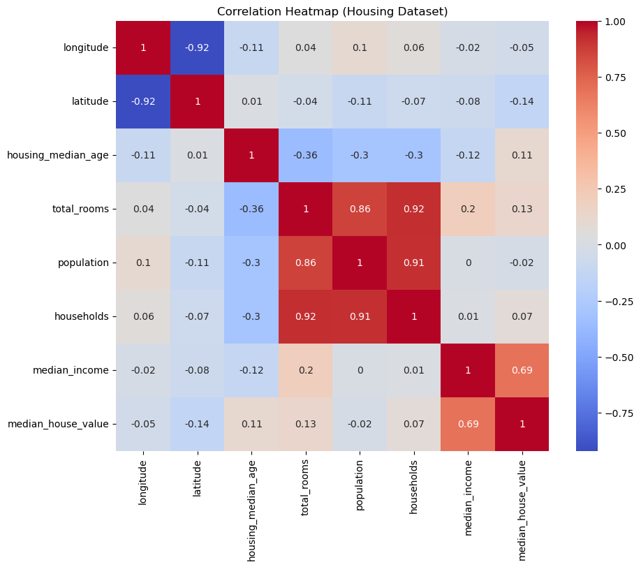

```python
import csv
import matplotlib.pyplot as plt
import seaborn as sns

# -----------------------------
# Load numerical columns
# -----------------------------
def load_numerical_columns(filepath):
    numerical_data = {
        "longitude": [], "latitude": [], "housing_median_age": [],
        "total_rooms": [], "population": [], "households": [],
        "median_income": [], "median_house_value": []
    }

    with open(filepath, "r", newline="", encoding="utf-8") as f:
        reader = csv.DictReader(f)
        for row in reader:
            for key in numerical_data:
                val = row[key]
                numerical_data[key].append(float(val) if val != "" else None)

    return numerical_data


# -----------------------------
# Basic statistics (YOUR STYLE)
# -----------------------------
def mean(data):
    return sum(data) / len(data)

def std_dev(data):
    m = mean(data)
    var = sum((x - m) ** 2 for x in data) / (len(data) - 1)
    return var ** 0.5

def covariance(data1, data2):
    m1 = mean(data1)
    m2 = mean(data2)

    cov_sum = 0
    for x, y in zip(data1, data2):
        cov_sum += (x - m1) * (y - m2)

    return cov_sum / (len(data1) - 1)

def correlation(x, y):
    return covariance(x, y) / (std_dev(x) * std_dev(y))


# -----------------------------
# Remove None values pairwise
# -----------------------------
def clean_pairs(x, y):
    clean_x, clean_y = [], []
    for a, b in zip(x, y):
        if a is not None and b is not None:
            clean_x.append(a)
            clean_y.append(b)
    return clean_x, clean_y


# -----------------------------
# Build correlation matrix
# -----------------------------
data = load_numerical_columns("housing.csv")
columns = list(data.keys())

corr_matrix = []

for col1 in columns:
    row = []
    for col2 in columns:
        x, y = clean_pairs(data[col1], data[col2])
        r = correlation(x, y)
        row.append(round(r, 2))
    corr_matrix.append(row)


# -----------------------------
# Plot heatmap
# -----------------------------
plt.figure(figsize=(10, 8))
sns.heatmap(
    corr_matrix,
    annot=True,
    xticklabels=columns,
    yticklabels=columns,
    cmap="coolwarm"
)
plt.title("Correlation Heatmap (Housing Dataset)")
plt.show()
```

**20. Explain how to interpret dark vs light colors in a heatmap.**

**Heatmap basics**

A correlation heatmap uses colors to show strength and direction of correlation between two variables.

Each cell in the heatmap = correlation coefficient

r ranges from -1 to +1

r value Meaning 1 Perfect positive correlation 0 No correlation -1 Perfect negative correlation

**Color interpretation** Heatmaps usually use a color scale like coolwarm:

Dark red / warm colors → high positive correlation (r close to +1)

Dark blue / cool colors → high negative correlation (r close to -1)

Light / white / pale colors → weak or no correlation (r near 0)

**21. Identify the strongest positive and negative correlations from the heatmap**

# Correlation Analysis of Housing Dataset

This document summarizes the strongest positive and negative correlations found in the housing dataset.

## Strongest Positive Correlations

These variables increase together — when one goes up, the other tends to go up too.

[output not shown]

## Strongest Negative Correlations

These variables move in opposite directions — when one goes up, the other tends to go down.

| Variable Pair | Correlation | Interpretation |
| --- | --- | --- |
| **longitude & latitude** | **–0.92** | As longitude increases, latitude decreases (geographic pattern) |
| **housing_median_age & total_rooms** | **–0.36** | Older houses tend to have fewer rooms |
| **housing_median_age & population** | **–0.30** | Older areas tend to have fewer people |

**22. Explain why diagonal values in correlation matrix are always 1.**

In a correlation matrix, the diagonal values are always 1 because each variable is being compared with itself. Correlation measures the strength and direction of a linear relationship between two variables, and when a variable is compared with itself, the relationship is perfectly linear. Using the Pearson correlation formula, the covariance of a variable with itself equals its variance, and dividing by the product of its standard deviations gives 1. Intuitively, this makes sense because a variable is always perfectly proportional to itself, so the correlation is maximum. These diagonal values serve as a reference, showing that each variable has perfect self-correlation, while the off-diagonal values represent correlations between different variables.

**23. Compare covariance matrix vs correlation matrix visually.**

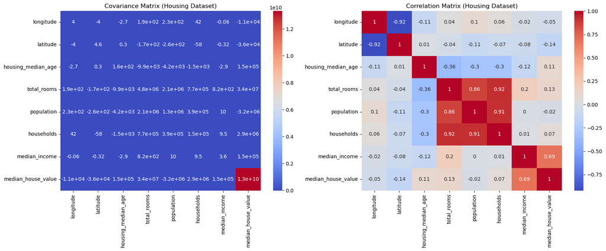

```python
import csv
import matplotlib.pyplot as plt
import seaborn as sns

# -----------------------------
# Load numerical columns
# -----------------------------
def load_numerical_columns(filepath):
    numerical_data = {
        "longitude": [], "latitude": [], "housing_median_age": [],
        "total_rooms": [], "population": [], "households": [],
        "median_income": [], "median_house_value": []
    }

    with open(filepath, "r", newline="", encoding="utf-8") as f:
        reader = csv.DictReader(f)
        for row in reader:
            for key in numerical_data:
                val = row[key]
                numerical_data[key].append(float(val) if val != "" else None)

    return numerical_data

# -----------------------------
# Basic statistics
# -----------------------------
def mean(data):
    return sum(data) / len(data)

def std_dev(data):
    m = mean(data)
    var = sum((x - m) ** 2 for x in data) / (len(data) - 1)
    return var ** 0.5

def covariance(data1, data2):
    m1 = mean(data1)
    m2 = mean(data2)
    cov_sum = sum((x - m1) * (y - m2) for x, y in zip(data1, data2))
    return cov_sum / (len(data1) - 1)

def correlation(x, y):
    return covariance(x, y) / (std_dev(x) * std_dev(y))

# -----------------------------
# Remove None values pairwise
# -----------------------------
def clean_pairs(x, y):
    clean_x, clean_y = [], []
    for a, b in zip(x, y):
        if a is not None and b is not None:
            clean_x.append(a)
            clean_y.append(b)
    return clean_x, clean_y

# -----------------------------
# Build covariance and correlation matrices
# -----------------------------
data = load_numerical_columns("housing.csv")
columns = list(data.keys())

cov_matrix = []
corr_matrix = []

for col1 in columns:
    cov_row = []
    corr_row = []
    for col2 in columns:
        x, y = clean_pairs(data[col1], data[col2])
        cov_val = covariance(x, y)
        corr_val = correlation(x, y)
        cov_row.append(round(cov_val, 2))
        corr_row.append(round(corr_val, 2))
    cov_matrix.append(cov_row)
    corr_matrix.append(corr_row)

# -----------------------------
# Plot side-by-side heatmaps
# -----------------------------
plt.figure(figsize=(17, 7))

# Covariance heatmap
plt.subplot(1, 2, 1)
sns.heatmap(
    cov_matrix,
    annot=True,
    xticklabels=columns,
    yticklabels=columns,
    cmap="coolwarm"
)
plt.title("Covariance Matrix (Housing Dataset)")

# Correlation heatmap
plt.subplot(1, 2, 2)
sns.heatmap(
    corr_matrix,
    annot=True,
    xticklabels=columns,
    yticklabels=columns,
    cmap="coolwarm"
)
plt.title("Correlation Matrix (Housing Dataset)")

plt.tight_layout()
plt.show()
```

**24. Choose two strongly correlated features and explain why.**

In the housing dataset, total_rooms and households have a very strong positive correlation of 0.92 because of their inherent relationship. Each household contributes one or more rooms, so regions with more households naturally have a higher total number of rooms. The correlation is strong because this relationship is nearly proportional—adding households almost always increases total rooms. This reflects a direct structural link: households are composed of rooms, so when one increases, the other increases as well. This strong positive relationship is clearly visible in the heatmap as a dark red cell, confirming that these features move together consistently.

**25. In which scenarios is correlation misleading? Explain using visualization.**

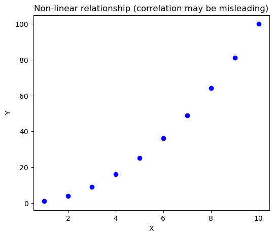

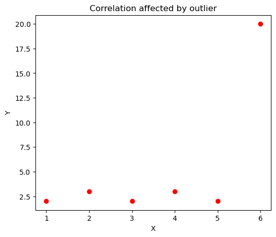

```python
import matplotlib.pyplot as plt

# Non-linear relationship
x = [1, 2, 3, 4, 5, 6, 7, 8, 9, 10]
y = [1, 4, 9, 16, 25, 36, 49, 64, 81, 100]  # y = x^2

plt.figure(figsize=(6,5))
plt.scatter(x, y, color='blue')
plt.title("Non-linear relationship (correlation may be misleading)")
plt.xlabel("X")
plt.ylabel("Y")
plt.show()

# Outlier example
x2 = [1, 2, 3, 4, 5, 6]
y2 = [2, 3, 2, 3, 2, 20]  # last point is an outlier

plt.figure(figsize=(6,5))
plt.scatter(x2, y2, color='red')
plt.title("Correlation affected by outlier")
plt.xlabel("X")
plt.ylabel("Y")
plt.show()
```

**When correlation can be misleading**

Correlation measures linear relationships between two variables, but it does not always tell the full story. Here are common scenarios where correlation can be misleading:

Example: 𝑦=𝑥^2

2️.**Outliers** A few extreme values can inflate or deflate correlation, giving a misleading impression of the relationship. Example: Most points are uncorrelated, but one outlier creates a strong correlation.

Visualization: Scatter plot with one extreme point shows an apparent trend that doesn’t reflect most data.